# 데이터 과학을 위한 저작도구: Computational Documents

대쉬보드(Dashboard)

[Tidyverse Korea](https://www.facebook.com/groups/tidyverse/)

2020-02-28

# 1 대쉬보드 [^1] [^2]

**A 12 Step Program to Quick Emailing Plots & Csvs**

1. Basic Layout
   - [`flexdashboard`](https://rmarkdown.rstudio.com/flexdashboard/)
2. Printing Tables, Descriptive Statistics, Model Summaries
   - `printr`, `summarytools::dfSummary`, `stargazer::stargazer`
   - [list of statistic codes](https://rdrr.io/cran/stargazer/man/stargazer_stat_code_list.html)
3. Interactive Datasets
   - `DT`
4. Interactive Plots
   - `highcharter`
   - 지도(`leaflet`), 시계열(`dygraphs`), `ggplots`(`plotly`)
5. Exporting
   - Datasets with `DT`
   - Highcharter Plots
6. CSS basics
7. Branding: Logos, Fonts, Colors
8. Header/Footer
9. Hosting
10. Automate-ish (Render + System())
11. Replicate (Render with arguments)
12. Automate or App it (cron, shiny runtime)

# 2 코로나19 대쉬보드

코로나19 대쉬보드를 제작하기 위해서 먼저 [코로나19 데이터](https://github.com/RamiKrispin/coronavirus)를 가져온다. 이를 [`flexdashboard`](https://rmarkdown.rstudio.com/flexdashboard/)를 주요 엔진삼아 대쉬보드를 제작하고 이를 `gh-pages` 웹사이트에 배포한다.

다행히 코로나19 데이터의 경우 [`coronavirus`](https://ramikrispin.github.io/coronavirus/) 데이터 팩키지가 제작되어 데이터 입수에 따른 공수를 절약할 수 있다.

[figure not shown]

대쉬보드 제작 흐름

## 2.1 데이터셋

```r
# install.packages("coronavirus")
# devtools::install_github("RamiKrispin/coronavirus")

library(coronavirus)

data("coronavirus")
coronavirus
```

```
# A tibble: 2,161 x 7
   Province.State Country.Region   Lat  Long date       cases type
   <chr>          <chr>          <dbl> <dbl> <date>     <int> <chr>
 1 ""             Japan           35.7  140. 2020-01-22     2 confirmed
 2 ""             South Korea     37.6  127. 2020-01-22     1 confirmed
 3 ""             Thailand        13.8  101. 2020-01-22     2 confirmed
 4 "Anhui"        Mainland China  31.8  117. 2020-01-22     1 confirmed
 5 "Beijing"      Mainland China  40.2  116. 2020-01-22    14 confirmed
 6 "Chongqing"    Mainland China  30.1  108. 2020-01-22     6 confirmed
 7 "Fujian"       Mainland China  26.1  118. 2020-01-22     1 confirmed
 8 "Guangdong"    Mainland China  23.3  113. 2020-01-22    26 confirmed
 9 "Guangxi"      Mainland China  23.8  109. 2020-01-22     2 confirmed
10 "Guizhou"      Mainland China  26.8  107. 2020-01-22     1 confirmed
# … with 2,151 more rows
```

## 2.2 대쉬보드 디자인

데이터 과학 요소가 들어간 대쉬보드 제작을 위한 UI 설계안을 작성한다.

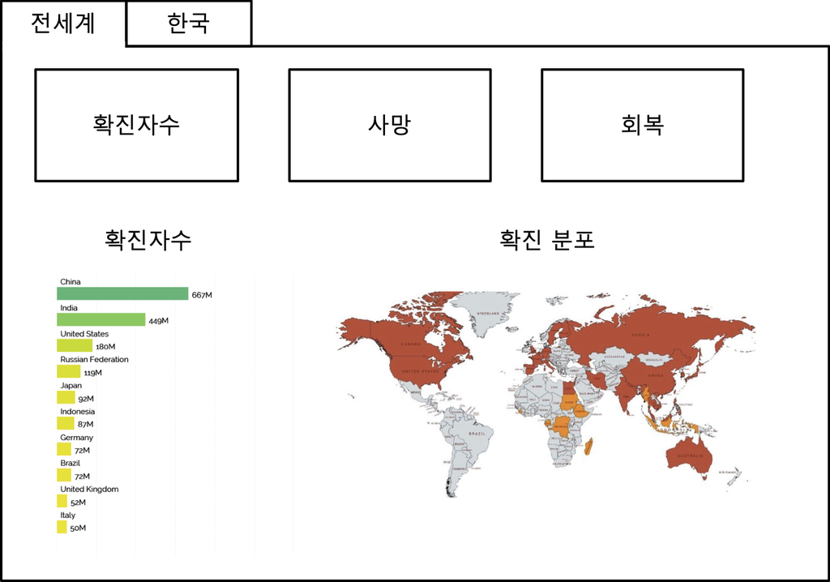

코로나19 대쉬보드 UI 설계

## 2.3 `flexdashboard` 배치도(layout)

- [Font Awesome](https://fontawesome.com/icons?from=io)
- [Ionicons](https://ionicons.com/)

[figure not shown]

`wireframe` 작성한 것을 `flexdashboard` 문법에 맞춰 대쉬보드 구성요소를 적절히 배치시킨다.

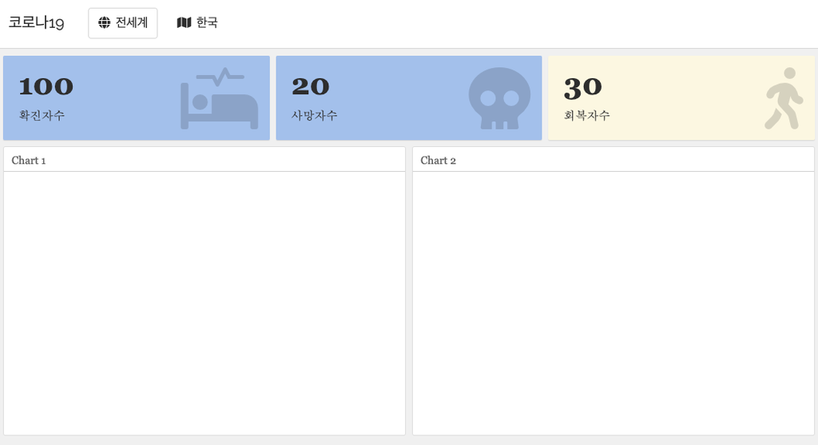

`flexdashboard` 배치도(layout)

상기 `flexdashboard` 배치도(layout)를 작성하기 위한 R마크다운 대쉬보드 코드는 다음과 같다. `valueBox`를 상단에 배치하고 아래 두 그래프 역영에 각기 필요한 그래프를 넣어준다.

````
---
layout: page
title: "데이터 과학을 위한 저작도구: Computational Documents"
subtitle: "대쉬보드(Dashboard)"
author:
    name: "[Tidyverse Korea](https://www.facebook.com/groups/tidyverse/)"
date: "2020-02-28"
output:
  html_document:
    toc: yes
    toc_float: true
    highlight: tango
    code_folding: show
    number_section: true
    self_contained: true
editor_options:
  chunk_output_type: console
---

전세계 {data-icon="fa-globe"}
===================================

Row {data-width=150}
--------------------------------------------

### 확진자수


```r
infected <- 100
valueBox(infected, icon = "fa-procedures")
```

### 사망자수


```r
death <- 20
valueBox(death, icon = "fa-skull")
```
````

[output cut: 9 more lines]

````
```


Column {data-height=350}
-------------------------------------

### Chart 1



### Chart 2


한국 {data-icon="fa-map"}
===================================
````

[^1]: [Marlorie Hughes (2019. 12. 3), “Dashboarding Like a Boss”, DC R Conference](https://www.youtube.com/watch?v=yott4quKN6s)
[^2]: [Sagar Kulkarni (Sep 20, 2019), “Building an HR Dashboard in R using Flexdashboard”, towrds data science](https://towardsdatascience.com/building-an-hr-dashboard-in-r-using-flexdashboard-76d14ed3f32)